# Visualizing the Future, Recruitment Assessment

Angela Zoss, Duke University Libraries

This summarizes the results of an internal survey of the [Visualizing the Future](https://visualizingthefuture.github.io) fellows to learn their thoughts on the recruitment process.

## Regarding the Call for Proposals

### Before applying, did you know any of the co-investigators through prior collaborations, workshop attendance, etc.?

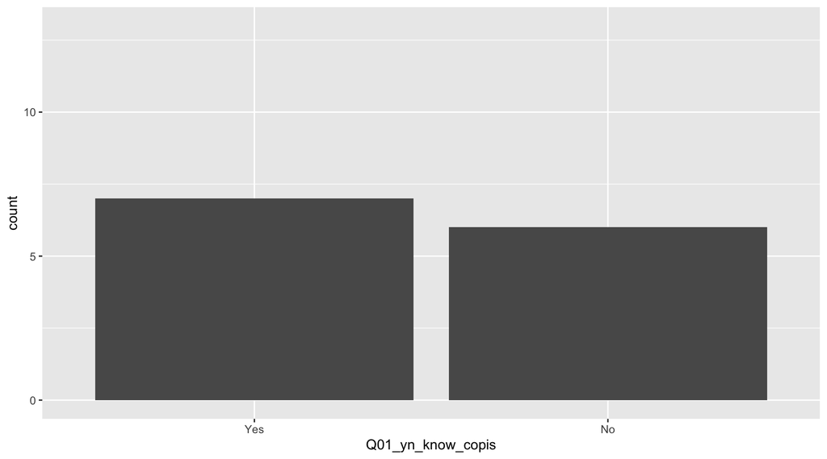

### Are you aware of anyone who wishes they would have applied but did not know about the application in time?

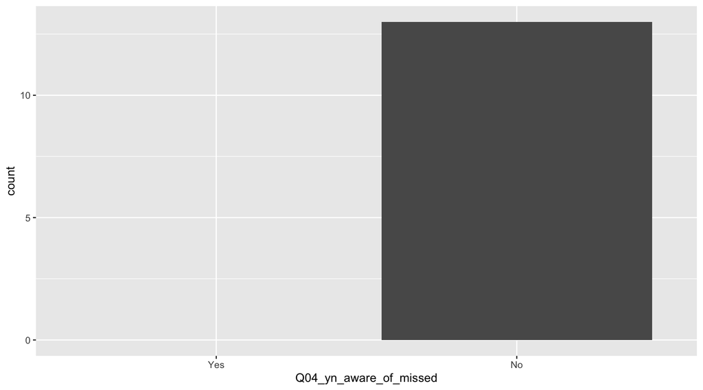

Back to top

## Preparing the Application

### Consider the type of application materials and the amount of work required to apply for this fellowship. Please indicate your level of agreement with the following statements.

#### The application materials required an appropriate amount of work for the scope of the fellowship.

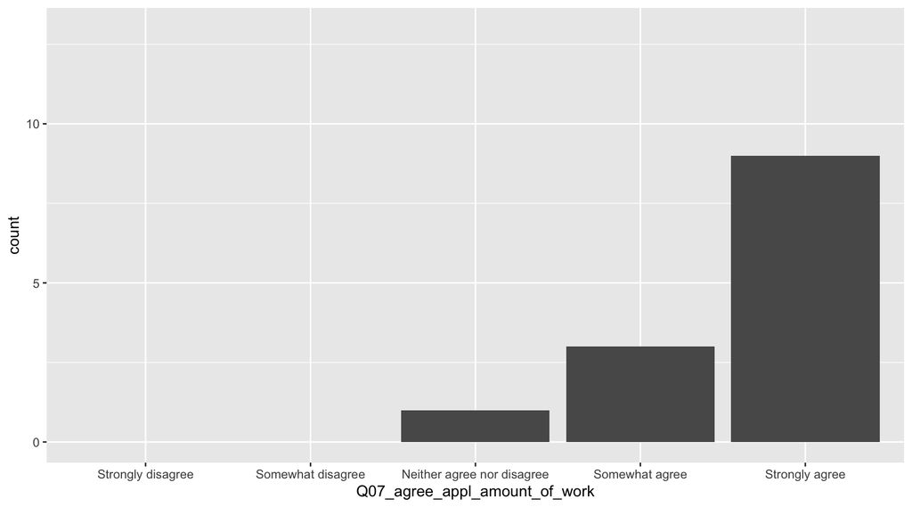

#### The application materials provided enough space to express my interest and proposed contributions.

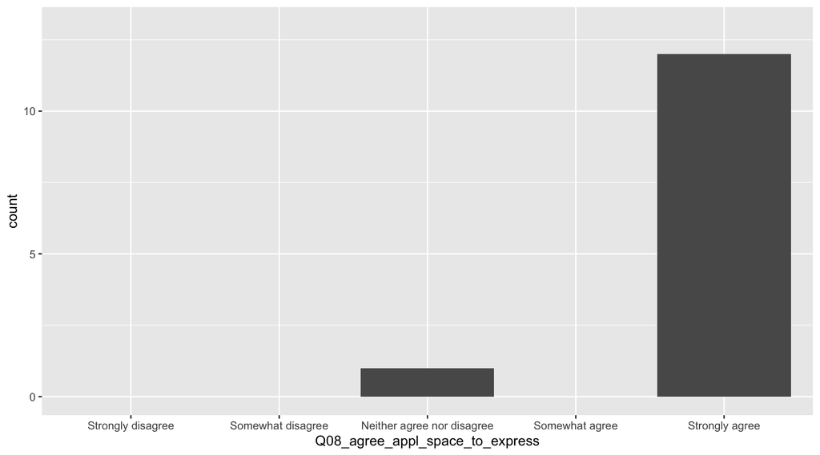

#### The type of materials requested were appropriate for the purpose of the fellowship.

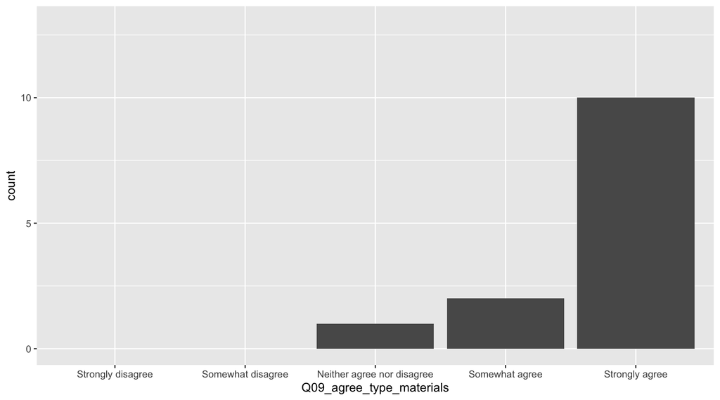

#### It was not overly burdensome to ask a supervisor or administrator for a letter of support.

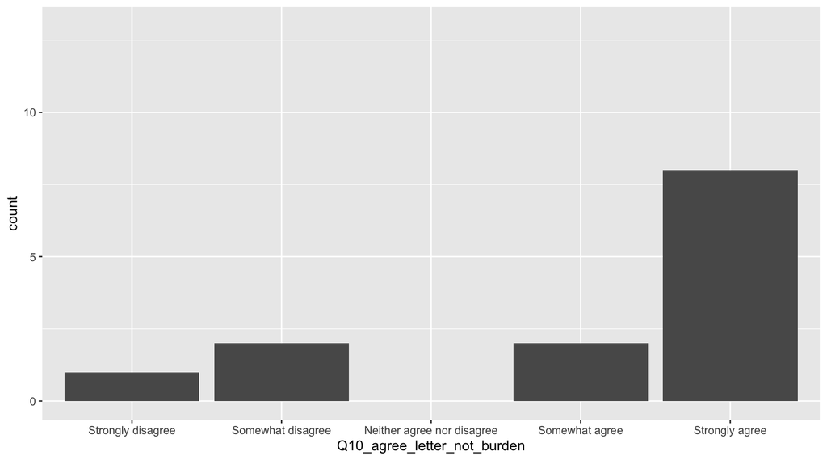

#### Obtaining the letter of support facilitated my ability to reserve time for this project.

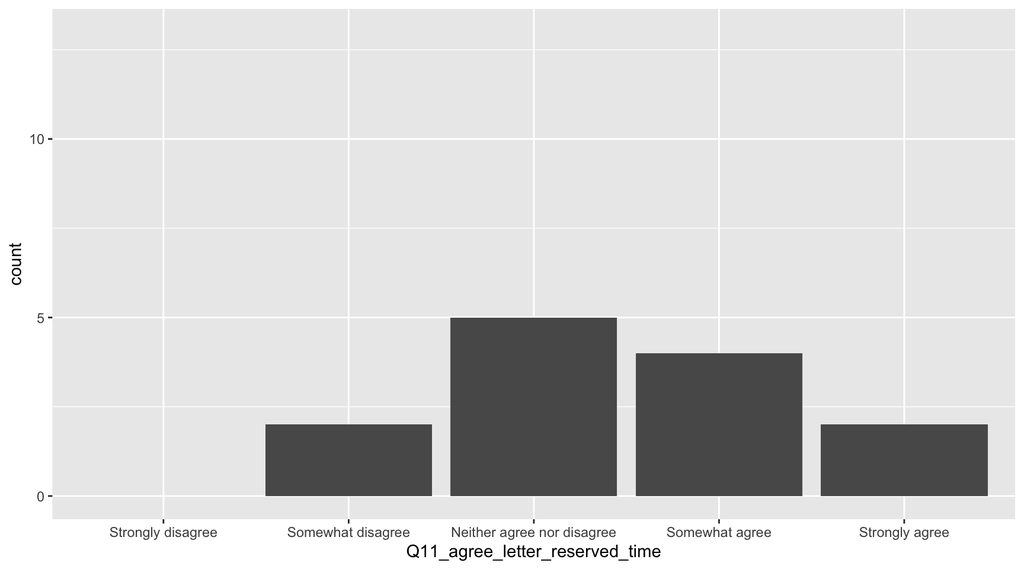

Back to top

## Reflecting on the Grant

### Please indicate your level of agreement with the following statements.

#### I felt that my institution and supervisors valued my application to/participation in this initiative

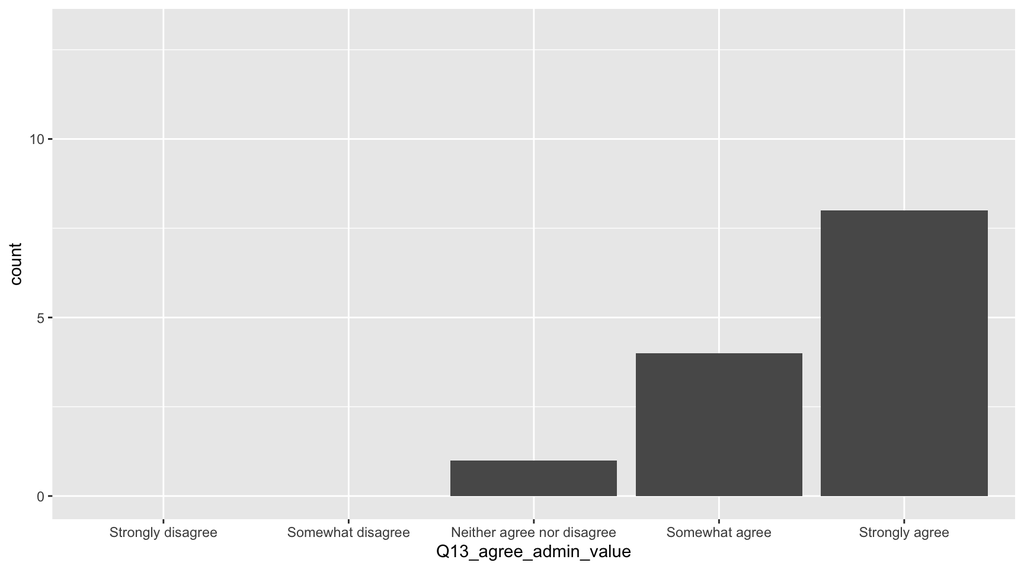

#### There were people at my institution who were willing/available to review my materials or strategize about the application.

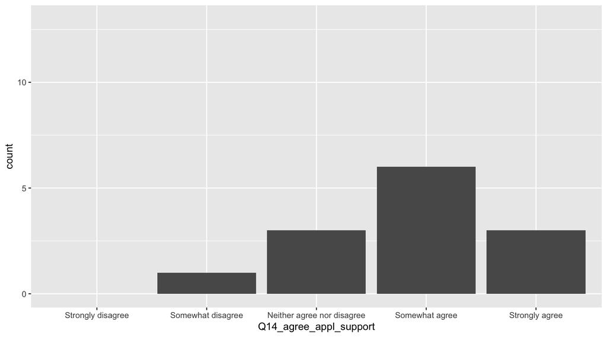

### Please indicate your level of agreement with the following statements.

#### The purpose of the grant was clear to me when I applied.

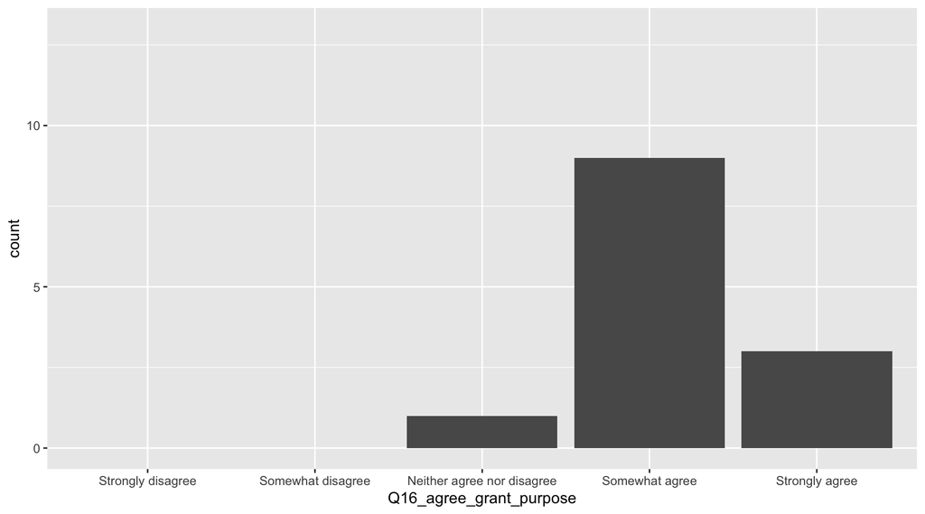

#### The participation requirements for fellows were clear to me when I applied.

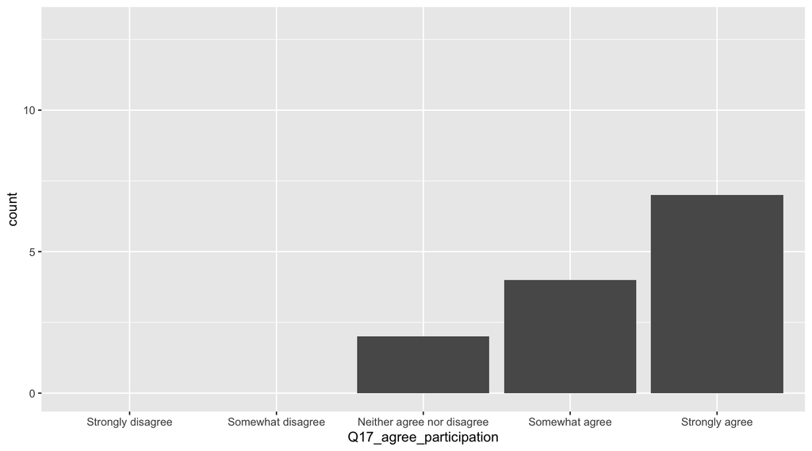

#### The evaluation criteria for my application was clear to me when I applied.

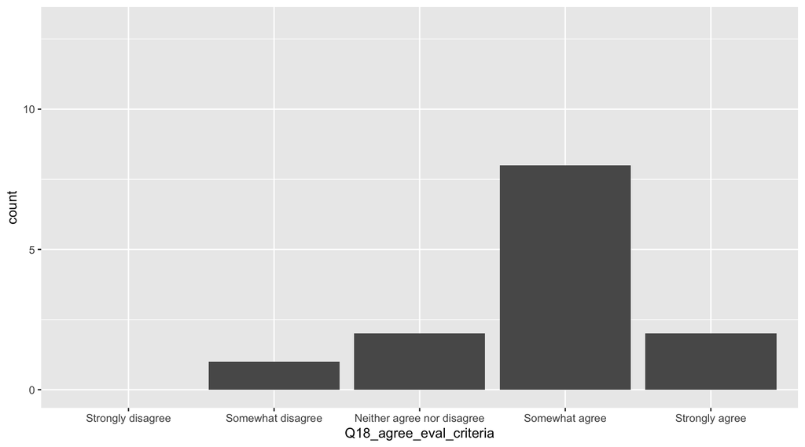

#### I felt comfortable addressing questions to the co-investigators during the application process.

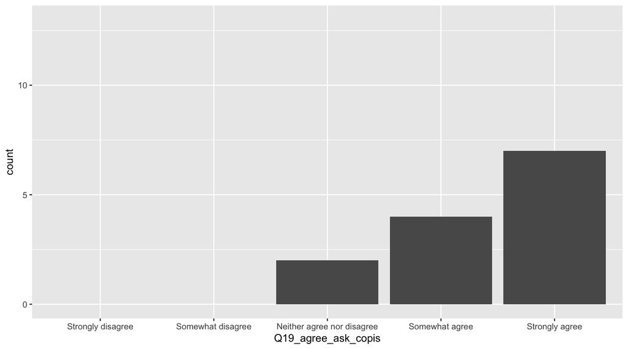

#### I feel the cohort selected represents a diversity of individuals.

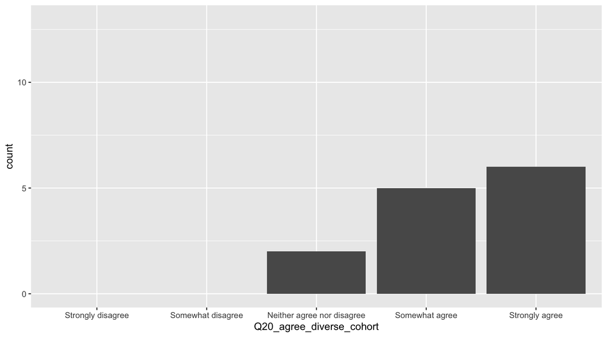

Back to top